# Olimpiadi di ginnastica artistica dal 1928 al 2016

## Domande

1. Esiste una relazione tra la prestazione di una ginnasta nei diversi attrezzi e le sue caratteristiche fisiche (peso e altezza)?
2. La fascia di età delle migliori ginnaste alle gare olimpiche si è modificata nel corso degli anni?
3. Le nazioni più forti nella ginnastica artistica sono cambiate nel corso degli anni?
4. Quali sono le nazioni che dal 1928 al 2016 hanno vinto più medaglie?

## Dataset utilizzati

I dataset utilizzati sono:

https://www.kaggle.com/datasets/heesoo37/120-years-of-olympic-history-athletes-and-results -> contiene 271116 righe e 15 colonne. Ogni riga corrisponde a un singolo atleta che gareggia in un evento olimpico, per il quale sono riportati età, altezza e peso.

https://www.kaggle.com/datasets/piterfm/olympic-games-medals-19862018?select=olympic_medals.csv -> contiene 21698 righe e 12 colonne. Il dataset include medaglie, atleti e nazionalità di ogni atleta.

## Domanda 1

**Esiste una relazione tra la prestazione di una ginnasta nei diversi attrezzi e le sue caratteristiche fisiche (peso e altezza)?**

Gli attrezzi della ginnastica artistica femminile sono:

[figure not shown]

**Corpo libero**

[figure not shown]

**Trave**

[figure not shown]

**Volteggio**

[figure not shown]

**Parallele**

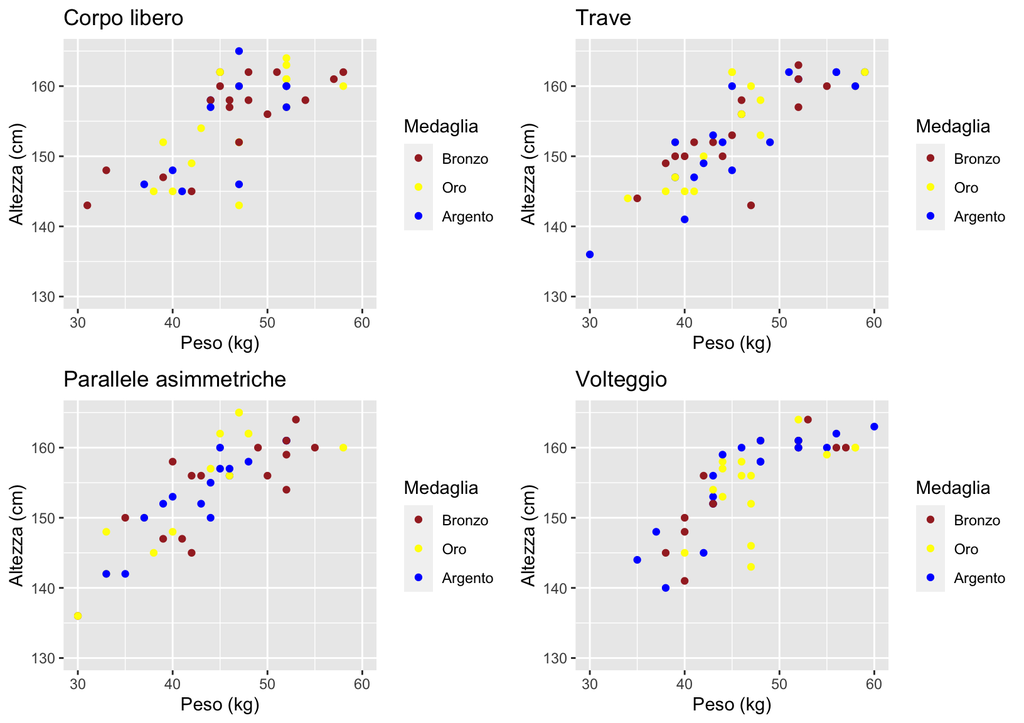

## Domanda 2

**La fascia di età delle migliori ginnaste alle gare olimpiche si è modificata nel corso degli anni?**

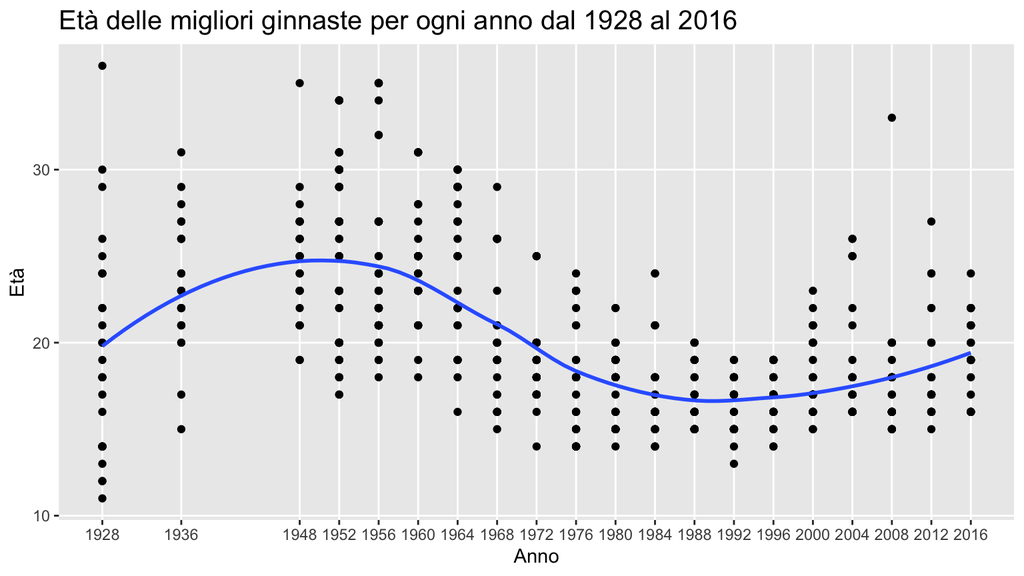

## Domanda 3

**Le nazioni più forti nella ginnastica artistica sono cambiate nel corso degli anni?**

[video not shown]

## Domanda 4

**Quali sono le nazioni che dal 1928 al 2016 hanno vinto più medaglie?**

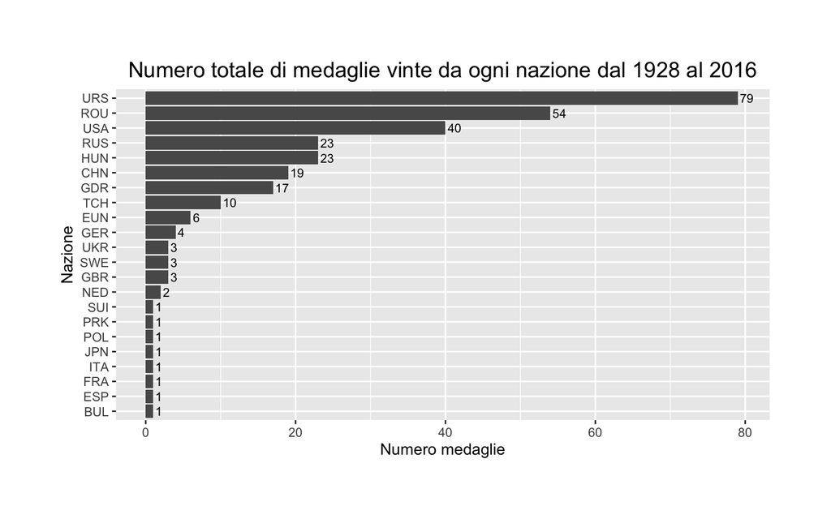